# Shiny App to Visualize Industry Trends

3/1/2018

## Product Overview

The app I developed is a tool for market researchers (or similar) to interact with industry data and understand how trends evolve over time within their industry.

My example focuses on the animated movie industry, and is geared towards people who are trying to understand how to allocate resources during movie production. It helps answer questions such as:

- How much money do animated movies make?
- How many animated movies are released per year?
- How big should my movie crew be, if I want to make a lot of money?
- Should I hire more animators, artists, or visual effects experts?

## Analysis and Calculations

ui.R sets up the user interface for the product server.R analyzes a dataset, and applies filters to present different datasets of interest to the user

```r
file <- list.files(pattern="moviedf.csv", full=TRUE)
df <- read.csv(file, header=TRUE, sep=",")
df_by_yr <- df[(df["year"] == 2006),]

# calculate and print the number of movies in a given year using nrow:
print(nrow(df_by_yr))
```

```
## [1] 51
```

## Overview of Product Interface

- A slider can be moved by the user, to scroll through year 1980 up to 2016
- The user can select buttons depending on what team they want to view (size of the animation team vs size of the writing team vs total crew size)
- The x-axis shows the IMDb rating for the movie
- The y-axis shows the total number of people who belonged to a selected team
- The bubble size and bubble color reflect how much money the movie made (movie gross, not movie profit).
- Lastly, the user can mouse over the bubbles to view the title of the movie!

## Product Interface

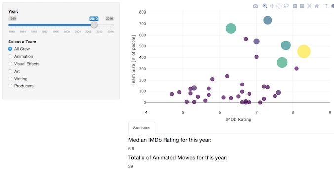

## Check Out My Shiny App!

Thank you for visiting. My app can be accessed here: http://irenium.shinyapps.io/shiny_app/